# Introduction to R & RStudio

Zhaohu(Jonathan) Fan

# Installing R

- Step 1. Go to https://cran.r-project.org/
- Step 2. Click “Download R for Mac/Windows”
- Step 3. Download the appropriate file:
  - Windows users click Base, and download the installer for the latest R version
  - Mac users select the file 4-3.X.X.pkg that aligns with your OS version
- Step 4. Follow the instructions of the installer.

# Installing RStudio

- Step 1. Go to RStudio for desktop https://www.rstudio.com/products/rstudio/download/
- Step 2. Select the install file for your OS operating system (OS)
- Step 3. Follow the instructions of the installer.

When you are done installing RStudio click on the icon that looks like:

[figure not shown]

and you should get a window that looks like the following:

[figure not shown]

# What is RStudio

- RStudio is running based on R. It is an IDE (Intergrated Development Environment) with many advanced features.
- This lab notes is created based R Markdown, a nice and useful tool from RStudio.

# We are now ready to start programming!

[figure not shown]

# Understanding the RStudio console

The RStudio console is where all the action happens. There are four fundamental windows: 1) $\color{green}{\text{script editor}}$, 2)$\color{red}{\text{ console}}$. 3) $\color{blue}{\text{ workspace environment}}$, and 4) $\color{purple}{\text{ misc.displays}}$.

[figure not shown]

# Understanding the RStudio: $\color{green}{\text{script editor}}$

**The top left window is where your script files (.R file or .Rmd file) will display.**

- To create a new (.R) file you use the **File** » **New File menu**.

[figure not shown]

- To open an existing (.R) file you use either the **File » Open File…** menu or the **Recent Files** menu to select from recently opened files.

[figure not shown]

# Understanding the RStudio: $\color{green}{\text{script editor}}$ cont’d

**The $\color{green}{\text{script editor}}$ is a great place to put code you care about.**

- Keep experimenting in the console, but once you have written code that works and does what you want, put it in the $\color{green}{\text{script editor}}$. - Save your scripts regularly and to back them up.

To execute the code in the $\color{green}{\text{script editor}}$ you have two options:

- Option 1. Place the cursor on the line that you would like to execute and execute Cmd/Ctrl + Enter. Alternatively, you could hit the **Run** button in the toolbar.
- Option 2. If you want to run all lines of code in the script then you can highlight the lines you want to run and then execute one of the options in #1.

[figure not shown]

# Understanding the RStudio: $\color{red}{\text{console}}$

**The bottom left window contains the console.**

- You can code directly in this window but it will not save your code.
- It is best to use this window when you are simply wanting to perform calculator type functions.
- This is also where your outputs will be presented when you run code in your script.
- Go ahead and type the following in your console:

[figure not shown]

# Understanding the RStudio: $\color{blue}{\text{workspace environment}}$

**The top right window is the workspace environment which captures much of your current R working environment and includes any user-defined objects (vectors, matrices, data frames, lists, functions).**

- When saving your R working session, these are the components along with the script files that will be saved in your working directory, which is the default location for all file inputs and outputs.
- $\color{blue}{\text{Q1: How to set up working directory?}}$

# Understanding the RStudio: $\color{blue}{\text{workspace environment}}$ cont’d

- $\color{blue}{\text{Approach 1 (recommended) }}$: Go to the following location in your toolbar **Session** » **Set Working Directory** » **Choose Directory** and select the directory of choice and click **Open**. Then your working directory is set!

[figure not shown]

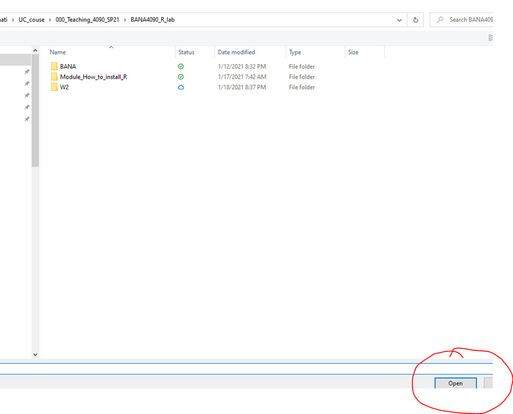

- At any time, you can check the current working directory by directly typing `getwd()`in R console.

[figure not shown]

# Understanding the RStudio: $\color{blue}{\text{workspace environment}}$ cont’d

- $\color{blue}{\text{ Approach 2}}$: alternatively, you can set the working directory to a specified directory by directly typing `setwd()` in R console

For example, the following code will set the working directory to C drive, folder “project1”,

[figure not shown]

# Understanding the RStudio: $\color{purple}{\text{misc.displays}}$

**The bottom right window contains multiple tabs.**

- The Files tab allows you to see which files are available in your working directory.

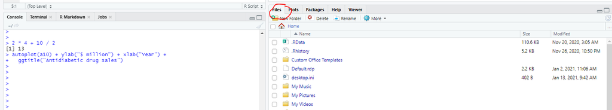

- The Plots tab will display any plots/graphics that are produced by your code.

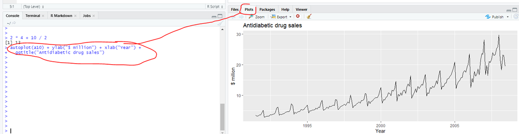

- The Packages tab will list all packages downloaded to your computer and also the ones that are loaded (more on this later).
- The Help tab allows you to search for topics you need help on and will also display any help responses (more on this later as well).

# **Let’s practice!**

- 1. Identify what working directory you are working out of.
- 2. Create a folder on your computer titled Learning R. Within R, set your working directory to this folder.
- 3. Type `pi` in the console. Set the option to show 8 digits. Type $\color{red}{\text{`options(digits = 8)`}}$, and re-type `pi` in the console.
- 4. Type `?pi` in the console. **Note that documentation on this object pops up in the Help tab in the Misc. Display.**
- 5. Now check out your code History tab.
- 6. Create a new .R file and save this as `my- first-script`(note how this now appears in your Learning R folder). Type `pi` in line 1 of this script, options(digits = 8) in line 2, and `pi` again in line 3. Execute this code one line at a time and then re-execute all lines at once.

Note: I provide R code for most examples in shaded boxes (so-called R chunks, shown in grey) like this:

```r
pi
```

```
## [1] 3.141593
```

# Summary

Typically, the Rstudio has four windows or panes: 1) $\color{green}{\text{script editor}}$, 2)$\color{red}{\text{ console}}$. 3) $\color{blue}{\text{ workspace environment}}$, and 4) $\color{purple}{\text{ misc.displays}}$.

[figure not shown]